# P8130 Final Report

2020/12/8

## Import dataset

```r
hate_crime_data =
  read_csv("./HateCrimes.csv") %>%
  janitor::clean_names()
```

## Inspect NAs

```r
hate_crime_data %>%
  sapply(.,function(x) sum(is.na(x)))
```

```
##                                   state                            unemployment
##                                       0                                       0
##                            urbanization                 median_household_income
##                                       0                                       0
## perc_population_with_high_school_degree                        perc_non_citizen
##                                       0                                       3
##                              gini_index                          perc_non_white
##                                       0                                       0
##               hate_crimes_per_100k_splc
##                                       0
```

Drop NAs

```r
hate_crime_df =
  hate_crime_data %>%
  naniar::replace_with_na(
    replace = list(hate_crimes_per_100k_splc = "N/A")
    ) %>%
  drop_na() %>%
  mutate(
    hate_crimes_per_100k_splc = as.numeric(hate_crimes_per_100k_splc),
    unemployment = factor(unemployment, levels = c("low","high")),
    urbanization = factor(urbanization, levels = c("low","high"))
  )
```

## Descriptive Data Analysis

### Catrgorical Variables

Unemployment

```r
hate_crime_df %>%
  group_by(unemployment) %>%
  summarise(
    count = n(),
    percentage = n()/nrow(hate_crime_df)
  ) %>%
  knitr::kable(digits = 2)
```

| unemployment | count | percentage |
| --- | --- | --- |
| low | 22 | 0.49 |
| high | 23 | 0.51 |

Urbanization

```r
hate_crime_df %>%
  group_by(urbanization) %>%
  summarise(
    count = n(),
    percentage = n()/nrow(hate_crime_df)
  ) %>%
  knitr::kable(digits = 2)
```

| urbanization | count | percentage |
| --- | --- | --- |
| low | 21 | 0.47 |
| high | 24 | 0.53 |

```r
gini_level =
  hate_crime_df %>%
  mutate(
    gini_index = case_when(
     gini_index >= 0.455 ~ 'High',
     gini_index < 0.455 ~ 'Low'
    ))


my_controls = tableby.control(
  test = T,
  numeric.stats = c("meansd", "medianq1q3", "range"),
  cat.stats = c("countpct", "Nmiss2"),
  stats.labels = list(
    meansd = "Mean (SD)",
    medianq1q3 = "Median (Q1, Q3)",
    range = "Min - Max"
  )
)

table_one <- tableby(
  gini_index ~ urbanization + unemployment + median_household_income + perc_population_with_high_school_degree + perc_non_citizen + perc_non_white + hate_crimes_per_100k_splc,
  data = gini_level,
  control = my_controls
)

summary(table_one,
        title = "Summary Statistic by level of hate crime rate", text = T)
```

```
##
## Table: Summary Statistic by level of hate crime rate
##
## |                                        |           High (N=24)            |            Low (N=21)            |           Total (N=45)           | p value|
## |:---------------------------------------|:--------------------------------:|:--------------------------------:|:--------------------------------:|-------:|
## |urbanization                            |                                  |                                  |                                  |   0.012|
## |-  low                                  |            7 (29.2%)             |            14 (66.7%)            |            21 (46.7%)            |        |
## |-  high                                 |            17 (70.8%)            |            7 (33.3%)             |            24 (53.3%)            |        |
## |-  Nmiss2                               |                0                 |                0                 |                0                 |        |
## |unemployment                            |                                  |                                  |                                  | < 0.001|
## |-  low                                  |            6 (25.0%)             |            16 (76.2%)            |            22 (48.9%)            |        |
## |-  high                                 |            18 (75.0%)            |            5 (23.8%)             |            23 (51.1%)            |        |
## |-  Nmiss2                               |                0                 |                0                 |                0                 |        |
## |median_household_income                 |                                  |                                  |                                  |   0.189|
## |-  Mean (SD)                            |       53641.958 (8891.711)       |       57193.810 (8910.788)       |       55299.489 (8979.492)       |        |
## |-  Median (Q1, Q3)                      | 54092.500 (45837.250, 60600.250) | 57522.000 (51102.000, 60708.000) | 54916.000 (48060.000, 60708.000) |        |
## |-  Min - Max                            |      42278.000 - 70161.000       |      39552.000 - 76165.000       |      39552.000 - 76165.000       |        |
## |perc_population_with_high_school_degree |                                  |                                  |                                  | < 0.001|
## |-  Mean (SD)                            |          0.848 (0.027)           |          0.888 (0.025)           |          0.867 (0.033)           |        |
## |-  Median (Q1, Q3)                      |       0.845 (0.827, 0.869)       |       0.897 (0.876, 0.908)       |       0.871 (0.839, 0.893)       |        |
## |-  Min - Max                            |          0.799 - 0.893           |          0.828 - 0.915           |          0.799 - 0.915           |        |
## |perc_non_citizen                        |                                  |                                  |                                  |   0.010|
## |-  Mean (SD)                            |          0.066 (0.033)           |          0.043 (0.023)           |          0.055 (0.031)           |        |
## |-  Median (Q1, Q3)                      |       0.060 (0.037, 0.092)       |       0.040 (0.030, 0.050)       |       0.050 (0.030, 0.080)       |        |
## |-  Min - Max                            |          0.020 - 0.130           |          0.010 - 0.100           |          0.010 - 0.130           |        |
## |perc_non_white                          |                                  |                                  |                                  | < 0.001|
## |-  Mean (SD)                            |          0.385 (0.133)           |          0.240 (0.128)           |          0.318 (0.149)           |        |
## |-  Median (Q1, Q3)                      |       0.375 (0.278, 0.465)       |       0.210 (0.160, 0.310)       |       0.300 (0.210, 0.420)       |        |
## |-  Min - Max                            |          0.150 - 0.630           |          0.060 - 0.500           |          0.060 - 0.630           |        |
## |hate_crimes_per_100k_splc               |                                  |                                  |                                  |   0.773|
## |-  Mean (SD)                            |          0.292 (0.290)           |          0.314 (0.205)           |          0.302 (0.252)           |        |
## |-  Median (Q1, Q3)                      |       0.219 (0.170, 0.327)       |       0.247 (0.144, 0.404)       |       0.226 (0.144, 0.351)       |        |
## |-  Min - Max                            |          0.069 - 1.522           |          0.105 - 0.833           |          0.069 - 1.522           |        |
```

Below is a summary table of all continuous variables group by unemployment status.

```r
my_controls = tableby.control(
  test = T,
  numeric.stats = c("meansd", "medianq1q3", "range"),
  cat.stats = c("countpct", "Nmiss2"),
  stats.labels = list(
    meansd = "Mean (SD)",
    medianq1q3 = "Median (Q1, Q3)",
    range = "Min - Max"
  )
)

table_one <- tableby(
  unemployment ~ hate_crimes_per_100k_splc + median_household_income + perc_population_with_high_school_degree + perc_non_citizen + perc_non_white + gini_index,
  data = hate_crime_df,
  control = my_controls
)

summary(table_one,
        title = "Summary Statistic by Unemployment", text = T)
```

Summary Statistic by Unemployment

|  | low (N=22) | high (N=23) | Total (N=45) | p value |
| --- | --- | --- | --- | --- |
| hate_crimes_per_100k_splc |  |  |  | 0.914 |
| - Mean (SD) | 0.307 (0.155) | 0.298 (0.322) | 0.302 (0.252) |  |
| - Median (Q1, Q3) | 0.323 (0.167, 0.386) | 0.200 (0.134, 0.290) | 0.226 (0.144, 0.351) |  |
| - Min - Max | 0.105 - 0.631 | 0.069 - 1.522 | 0.069 - 1.522 |  |
| median_household_income |  |  |  | 0.092 |
| - Mean (SD) | 57604.000 (8341.096) | 53095.174 (9190.238) | 55299.489 (8979.492) |  |
| - Median (Q1, Q3) | 57196.000 (52363.250, 62598.250) | 49875.000 (45534.500, 58971.500) | 54916.000 (48060.000, 60708.000) |  |
| - Min - Max | 42786.000 - 76165.000 | 39552.000 - 70161.000 | 39552.000 - 76165.000 |  |
| perc_population_with_high_school_degree |  |  |  | 0.002 |
| - Mean (SD) | 0.882 (0.031) | 0.852 (0.028) | 0.867 (0.033) |  |
| - Median (Q1, Q3) | 0.890 (0.868, 0.903) | 0.843 (0.829, 0.873) | 0.871 (0.839, 0.893) |  |
| - Min - Max | 0.799 - 0.915 | 0.806 - 0.914 | 0.799 - 0.915 |  |
| perc_non_citizen |  |  |  | 0.111 |
| - Mean (SD) | 0.048 (0.027) | 0.063 (0.034) | 0.055 (0.031) |  |
| - Median (Q1, Q3) | 0.040 (0.030, 0.057) | 0.060 (0.035, 0.085) | 0.050 (0.030, 0.080) |  |
| - Min - Max | 0.010 - 0.110 | 0.010 - 0.130 | 0.010 - 0.130 |  |
| perc_non_white |  |  |  | 0.003 |
| - Mean (SD) | 0.253 (0.131) | 0.379 (0.141) | 0.318 (0.149) |  |
| - Median (Q1, Q3) | 0.215 (0.165, 0.340) | 0.370 (0.275, 0.470) | 0.300 (0.210, 0.420) |  |
| - Min - Max | 0.060 - 0.560 | 0.070 - 0.630 | 0.060 - 0.630 |  |
| gini_index |  |  |  | 0.005 |
| - Mean (SD) | 0.447 (0.019) | 0.464 (0.020) | 0.456 (0.021) |  |
| - Median (Q1, Q3) | 0.444 (0.433, 0.456) | 0.464 (0.455, 0.470) | 0.455 (0.441, 0.467) |  |
| - Min - Max | 0.419 - 0.499 | 0.422 - 0.532 | 0.419 - 0.532 |  |

Then a summary table of all continuous variables group by urbanization status.

```r
table_two <- tableby(
  urbanization ~ hate_crimes_per_100k_splc + median_household_income + perc_population_with_high_school_degree + perc_non_citizen + perc_non_white + gini_index,
  data = hate_crime_df,
  control = my_controls
)

summary(table_two,
        title = "Summary Statistic by Urbanization", text = T)
```

Summary Statistic by Urbanization

|  | low (N=21) | high (N=24) | Total (N=45) | p value |
| --- | --- | --- | --- | --- |
| hate_crimes_per_100k_splc |  |  |  | 0.161 |
| - Mean (SD) | 0.246 (0.142) | 0.352 (0.313) | 0.302 (0.252) |  |
| - Median (Q1, Q3) | 0.210 (0.144, 0.324) | 0.270 (0.176, 0.375) | 0.226 (0.144, 0.351) |  |
| - Min - Max | 0.069 - 0.627 | 0.078 - 1.522 | 0.069 - 1.522 |  |
| median_household_income |  |  |  | 0.083 |
| - Mean (SD) | 52818.667 (9085.982) | 57470.208 (8481.033) | 55299.489 (8979.492) |  |
| - Median (Q1, Q3) | 51102.000 (46686.000, 57810.000) | 58077.500 (51472.500, 63209.000) | 54916.000 (48060.000, 60708.000) |  |
| - Min - Max | 39552.000 - 73397.000 | 42406.000 - 76165.000 | 39552.000 - 76165.000 |  |
| perc_population_with_high_school_degree |  |  |  | 0.296 |
| - Mean (SD) | 0.872 (0.036) | 0.862 (0.029) | 0.867 (0.033) |  |
| - Median (Q1, Q3) | 0.876 (0.836, 0.908) | 0.869 (0.841, 0.887) | 0.871 (0.839, 0.893) |  |
| - Min - Max | 0.817 - 0.915 | 0.799 - 0.904 | 0.799 - 0.915 |  |
| perc_non_citizen |  |  |  | < 0.001 |
| - Mean (SD) | 0.033 (0.014) | 0.075 (0.029) | 0.055 (0.031) |  |
| - Median (Q1, Q3) | 0.030 (0.030, 0.040) | 0.080 (0.057, 0.100) | 0.050 (0.030, 0.080) |  |
| - Min - Max | 0.010 - 0.060 | 0.020 - 0.130 | 0.010 - 0.130 |  |
| perc_non_white |  |  |  | < 0.001 |
| - Mean (SD) | 0.238 (0.136) | 0.388 (0.124) | 0.318 (0.149) |  |
| - Median (Q1, Q3) | 0.210 (0.150, 0.350) | 0.375 (0.278, 0.482) | 0.300 (0.210, 0.420) |  |
| - Min - Max | 0.060 - 0.620 | 0.190 - 0.630 | 0.060 - 0.630 |  |
| gini_index |  |  |  | 0.003 |
| - Mean (SD) | 0.446 (0.015) | 0.464 (0.022) | 0.456 (0.021) |  |
| - Median (Q1, Q3) | 0.445 (0.433, 0.458) | 0.465 (0.451, 0.472) | 0.455 (0.441, 0.467) |  |
| - Min - Max | 0.422 - 0.472 | 0.419 - 0.532 | 0.419 - 0.532 |  |

## Normality Test

Histogram

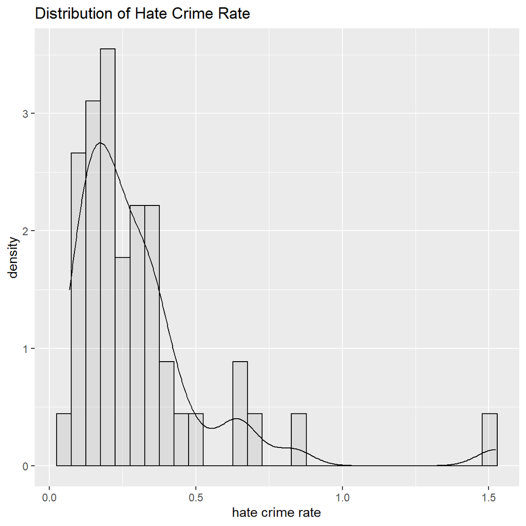

```r
hate_crime_df %>%
  ggplot(aes(x = hate_crimes_per_100k_splc, y = ..density..)) +
  geom_histogram(colour = "black", alpha = 0.1) +
  geom_density(alpha = 0.4) +
  labs(
    x = "hate crime rate",
    title = "Distribution of Hate Crime Rate"
  )
```

qq plot

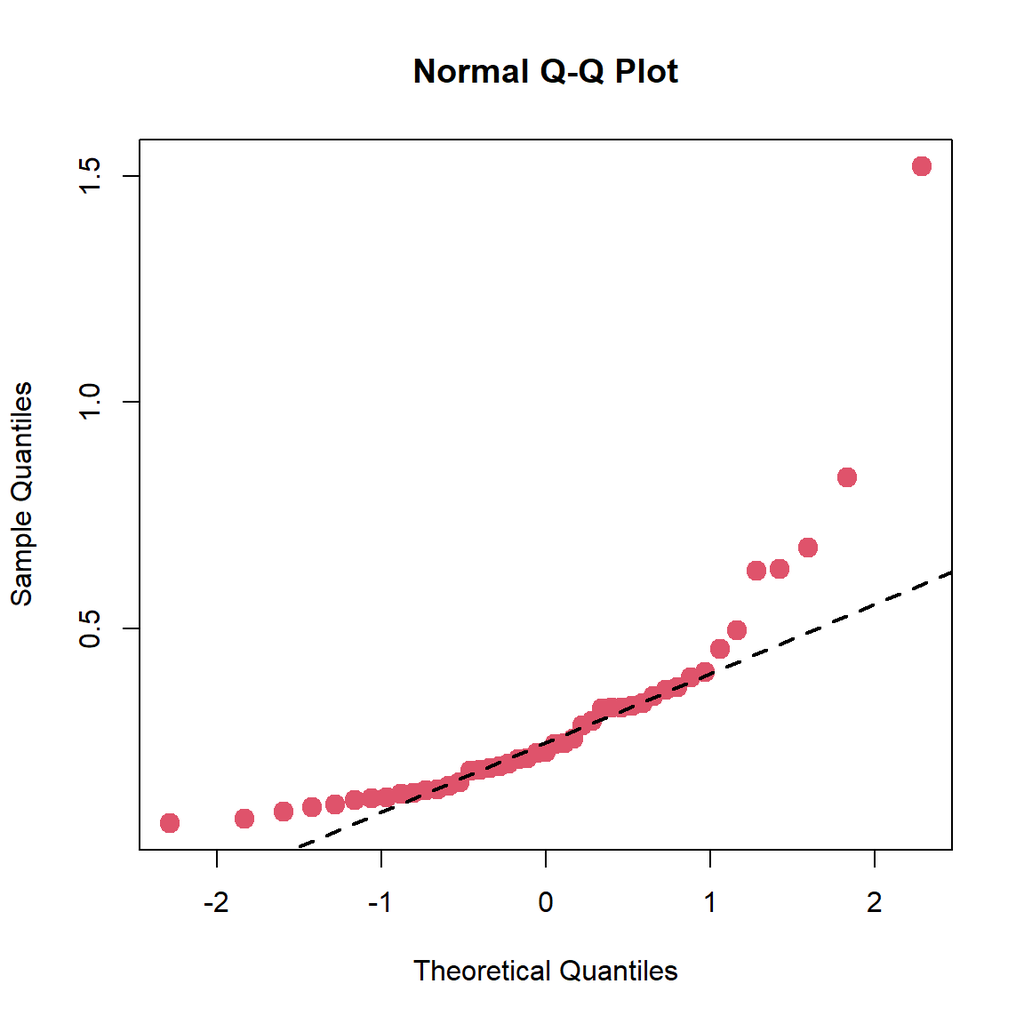

```r
qqnorm(hate_crime_df$hate_crimes_per_100k_splc, col=2, pch=19, cex=1.5)
qqline(hate_crime_df$hate_crimes_per_100k_splc, col = 1,lwd=2,lty=2)
```

The distribution of hate crime rate is heavily right skewed.

## Tansformation

distribution of ln(hate_crimes_per_100k_splc)

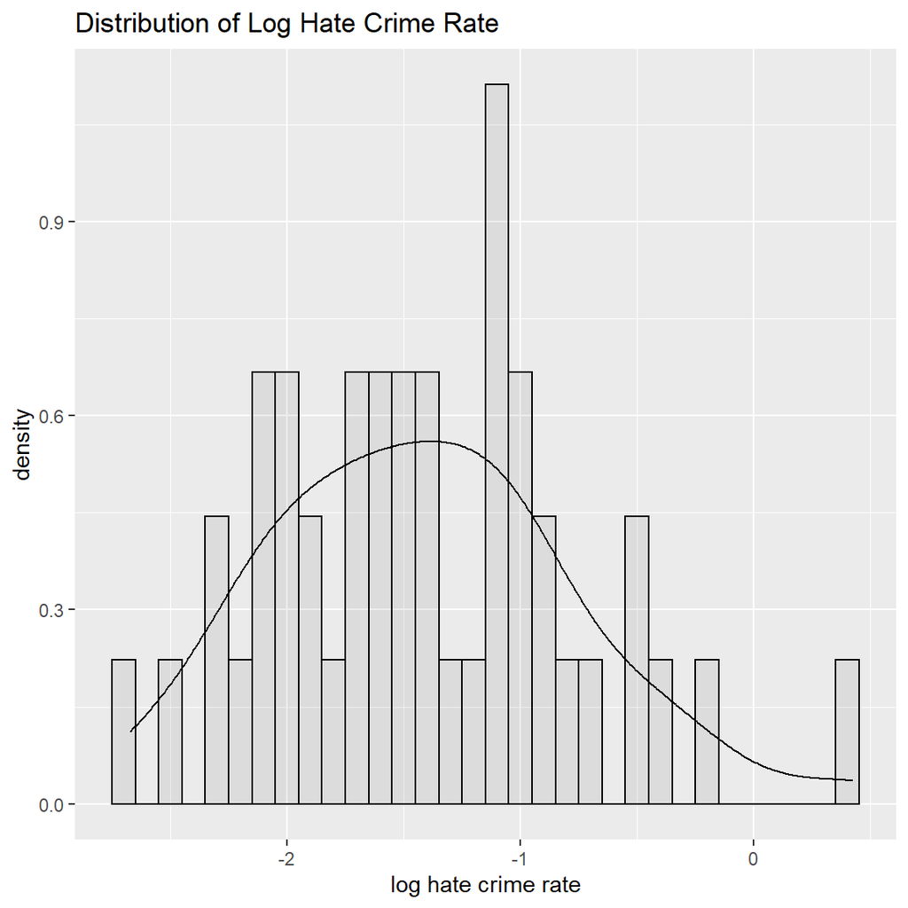

```r
trans_hate_crime_df =
hate_crime_df %>%
  mutate(
    hate_crimes_per_100k_splc =
      log(hate_crimes_per_100k_splc)
  )

trans_hate_crime_df %>%
  ggplot(aes(x = hate_crimes_per_100k_splc, y = ..density..)) +
  geom_histogram(binwidth = 0.1, colour = "black", alpha = 0.1) +
  geom_density(alpha = 0.4) +
  labs(
    x = "log hate crime rate",
    title = "Distribution of Log Hate Crime Rate"
  )
```

qq plot

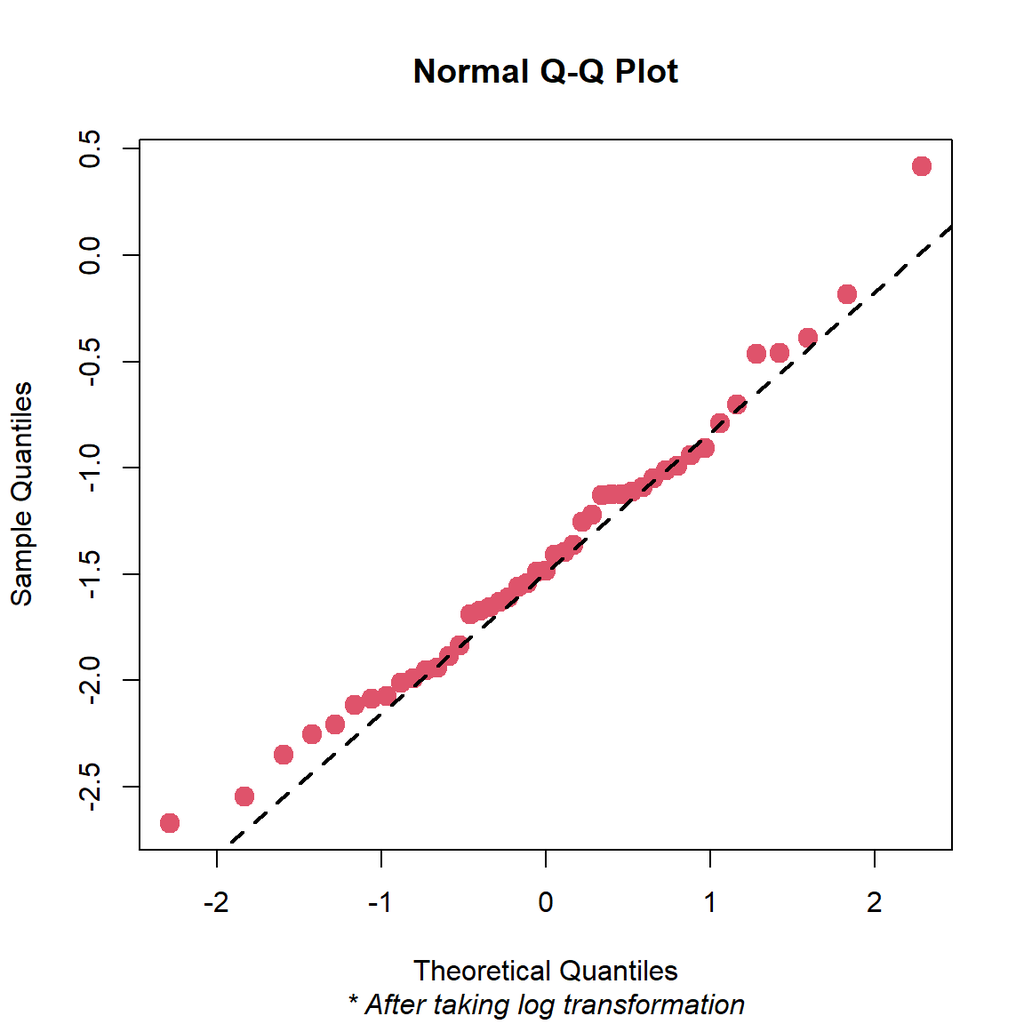

```r
qqnorm(trans_hate_crime_df$hate_crimes_per_100k_splc, col=2, pch=19, cex=1.5)
qqline(trans_hate_crime_df$hate_crimes_per_100k_splc, col = 1,lwd=2,lty=2)
title(sub = "* After taking log transformation", font.sub = 3)
```

It's much better now.

## Outliers

Make plot for gini_index vs hate crime rate

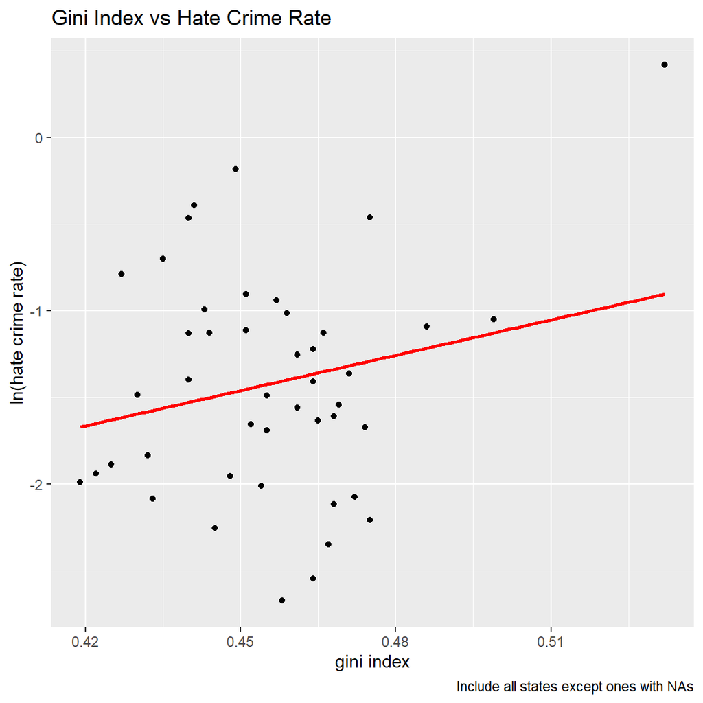

```r
trans_hate_crime_df %>%
 ggplot(aes(x = gini_index, y = hate_crimes_per_100k_splc)) +
  geom_point() +
  geom_smooth(method = "lm", se = F, color = "red") +
  labs(
    y = "ln(hate crime rate)",
    x = "gini index",
    title = "Gini Index vs Hate Crime Rate",
    caption = "Include all states except ones with NAs"
  )
```

Based on the plot above, there is positive association between gini index and hate crime rate.

Find potential influential outliers

```r
fit_all = lm(hate_crimes_per_100k_splc ~.-state, data = trans_hate_crime_df)

summary(fit_all)
```

```
##
## Call:
## lm(formula = hate_crimes_per_100k_splc ~ . - state, data = trans_hate_crime_df)
##
## Residuals:
##      Min       1Q   Median       3Q      Max
## -1.28845 -0.41144  0.01898  0.31334  1.13022
##
## Coefficients:
##                                           Estimate Std. Error t value Pr(>|t|)
## (Intercept)                             -1.845e+01  5.521e+00  -3.342  0.00191
## unemploymenthigh                        -2.179e-01  2.088e-01  -1.043  0.30353
## urbanizationhigh                         9.885e-02  2.467e-01   0.401  0.69092
## median_household_income                 -4.732e-06  1.735e-05  -0.273  0.78658
## perc_population_with_high_school_degree  1.121e+01  5.341e+00   2.098  0.04275
## perc_non_citizen                         1.168e+00  5.464e+00   0.214  0.83189
## gini_index                               1.670e+01  5.744e+00   2.908  0.00611
## perc_non_white                          -1.232e-01  1.069e+00  -0.115  0.90887
##
## (Intercept)                             **
## unemploymenthigh
## urbanizationhigh
## median_household_income
## perc_population_with_high_school_degree *
## perc_non_citizen
## gini_index                              **
## perc_non_white
## ---
## Signif. codes:  0 '***' 0.001 '**' 0.01 '*' 0.05 '.' 0.1 ' ' 1
##
## Residual standard error: 0.5862 on 37 degrees of freedom
## Multiple R-squared:  0.3146, Adjusted R-squared:  0.1849
## F-statistic: 2.426 on 7 and 37 DF,  p-value: 0.03768
```

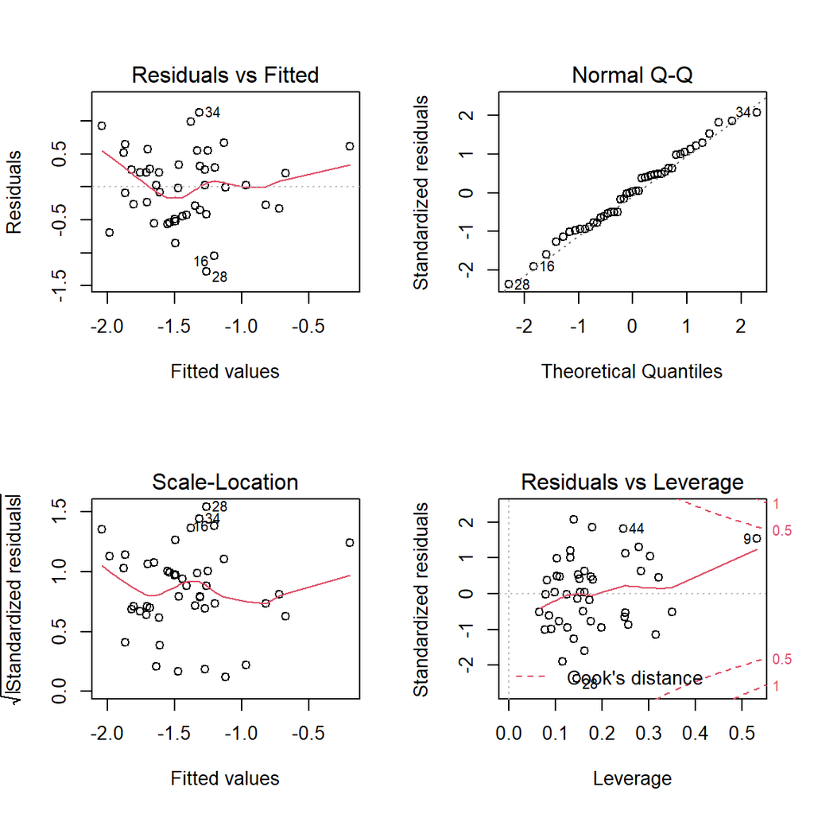

```r
par(mfrow=c(2,2))
plot(fit_all)
```

Notice row 9 is a potential influential point. It's the reocord for District of Columbia, which has very high hate crime rate.

Remove observation for District of Columbia and fit the full model again.

```r
trans_hate_crime_df_no_dc = trans_hate_crime_df[-c(9),]

fit_all_no_dc = lm(hate_crimes_per_100k_splc ~.-state, data = trans_hate_crime_df_no_dc)

summary(fit_all_no_dc)
```

```
##
## Call:
## lm(formula = hate_crimes_per_100k_splc ~ . - state, data = trans_hate_crime_df_no_dc)
##
## Residuals:
##      Min       1Q   Median       3Q      Max
## -1.17560 -0.35011  0.02951  0.35998  1.11574
##
## Coefficients:
##                                           Estimate Std. Error t value Pr(>|t|)
## (Intercept)                             -1.232e+01  6.694e+00  -1.840    0.074
## unemploymenthigh                        -2.235e-01  2.049e-01  -1.091    0.283
## urbanizationhigh                         1.986e-01  2.503e-01   0.793    0.433
## median_household_income                 -6.492e-06  1.706e-05  -0.380    0.706
## perc_population_with_high_school_degree  8.238e+00  5.575e+00   1.478    0.148
## perc_non_citizen                         1.568e+00  5.367e+00   0.292    0.772
## gini_index                               9.146e+00  7.431e+00   1.231    0.226
## perc_non_white                          -5.079e-01  1.078e+00  -0.471    0.640
##
## (Intercept)                             .
## unemploymenthigh
## urbanizationhigh
## median_household_income
## perc_population_with_high_school_degree
## perc_non_citizen
## gini_index
## perc_non_white
## ---
## Signif. codes:  0 '***' 0.001 '**' 0.01 '*' 0.05 '.' 0.1 ' ' 1
##
## Residual standard error: 0.5752 on 36 degrees of freedom
## Multiple R-squared:  0.2102, Adjusted R-squared:  0.05667
## F-statistic: 1.369 on 7 and 36 DF,  p-value: 0.2481
```

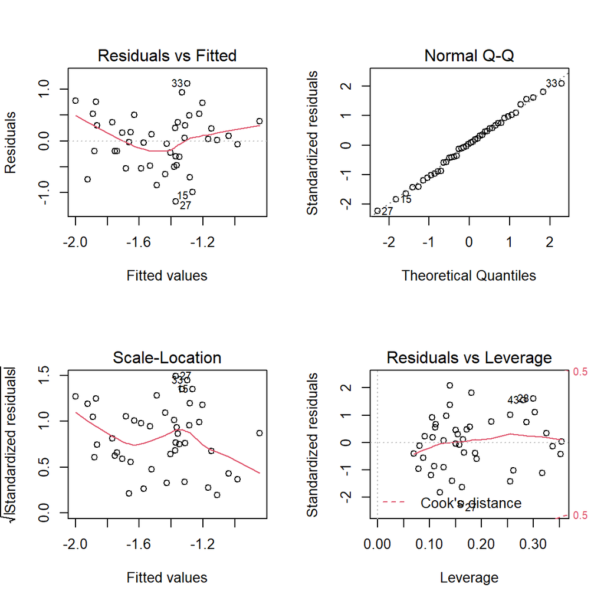

```r
par(mfrow=c(2,2))
plot(fit_all_no_dc)
```

Then take a look again at the relationship between gini index and hate crime rate

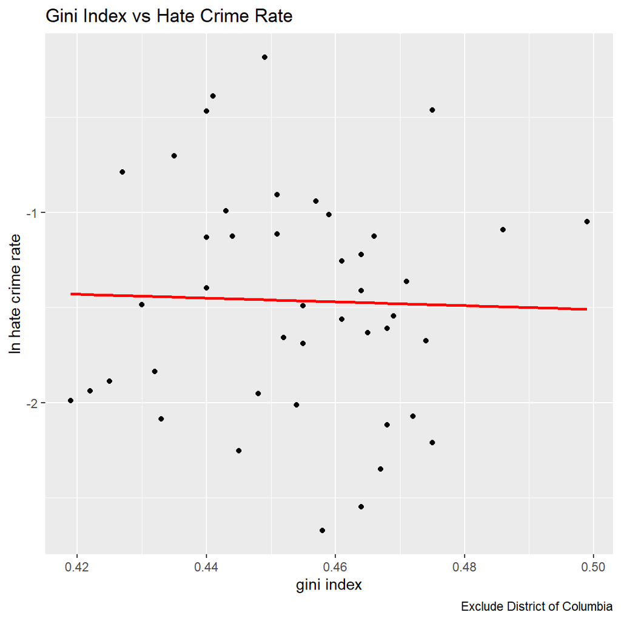

```r
trans_hate_crime_df_no_dc %>%
 ggplot(aes(x = gini_index, y = hate_crimes_per_100k_splc)) +
  geom_point() +
  geom_smooth(method = "lm", se = F, color = "red") +
  labs(
    y = "ln hate crime rate",
    x = "gini index",
    title = "Gini Index vs Hate Crime Rate",
    caption = "Exclude District of Columbia"
  )
```

There is slightly negative association between gini index and hate crime rate. The regression line is nearly horizontal, implying there maybe no linear relationship between gini index and hate frime rate. Removing row 9 has changed the regression results, which means that it's influential. We should exclude row 9.

## Test for Collinearity

Correlation matrix for all variables

```r
  trans_hate_crime_df_no_dc %>%
  rename(
    perc_hs_degree = perc_population_with_high_school_degree,
    hate_crime_rate = hate_crimes_per_100k_splc
  ) %>%
  dplyr::select(-state) %>%
  mutate(
    unemployment = as.numeric(unemployment),
    urbanization = as.numeric(urbanization)
  ) %>%
  cor(.,method = "pearson") %>%
  round(.,digits = 2) %>%
  head() %>%
  knitr::kable()
```

|  | unemployment | urbanization | median_household_income | perc_hs_degree | perc_non_citizen | gini_index | perc_non_white | hate_crime_rate |
| --- | --- | --- | --- | --- | --- | --- | --- | --- |
| unemployment | 1.00 | 0.23 | -0.30 | -0.46 | 0.21 | 0.40 | 0.41 | -0.26 |
| urbanization | 0.23 | 1.00 | 0.24 | -0.16 | 0.67 | 0.43 | 0.49 | 0.14 |
| median_household_income | -0.30 | 0.24 | 1.00 | 0.66 | 0.26 | -0.31 | -0.03 | 0.25 |
| perc_hs_degree | -0.46 | -0.16 | 0.66 | 1.00 | -0.28 | -0.66 | -0.53 | 0.32 |
| perc_non_citizen | 0.21 | 0.67 | 0.26 | -0.28 | 1.00 | 0.41 | 0.73 | 0.02 |
| gini_index | 0.40 | 0.43 | -0.31 | -0.66 | 0.41 | 1.00 | 0.47 | -0.03 |

We can see that

- `perc_non_white` and `perc_non_citizen` are highly correlated (0.73).
- `urbanization` and `perc_non_citizen` are moderately correlated (0.67)
- `perc_population_with_high_school_degree` and `median_household_income` are moderately correlated (0.66)
- `gini_index` and `perc_population_with_high_school_degree` has moderate correlation (-0.66)

VIF

```r
vif(fit_all_no_dc)
```

```
##                        unemploymenthigh                        urbanizationhigh
##                                1.395922                                2.079461
##                 median_household_income perc_population_with_high_school_degree
##                                2.970238                                4.407167
##                        perc_non_citizen                              gini_index
##                                3.470719                                2.214828
##                          perc_non_white
##                                3.064669
```

`perc_population_with_high_school_degree` and `perc_non_citizen` has quite high vif, while none of them exceed 5. Then we test whether removing `perc_population_with_high_school_degree` influences the regression results.

```r
fit_all_no_degree = lm(hate_crimes_per_100k_splc ~.-state -perc_population_with_high_school_degree, data = trans_hate_crime_df_no_dc)

summary(fit_all_no_degree)
```

```
##
## Call:
## lm(formula = hate_crimes_per_100k_splc ~ . - state - perc_population_with_high_school_degree,
##     data = trans_hate_crime_df_no_dc)
##
## Residuals:
##      Min       1Q   Median       3Q      Max
## -1.11695 -0.28274  0.07257  0.26791  1.20685
##
## Coefficients:
##                           Estimate Std. Error t value Pr(>|t|)
## (Intercept)             -3.676e+00  3.311e+00  -1.110    0.274
## unemploymenthigh        -2.458e-01  2.076e-01  -1.184    0.244
## urbanizationhigh         2.367e-01  2.530e-01   0.936    0.356
## median_household_income  1.051e-05  1.280e-05   0.821    0.417
## perc_non_citizen         6.001e-01  5.411e+00   0.111    0.912
## gini_index               4.269e+00  6.764e+00   0.631    0.532
## perc_non_white          -1.086e+00  1.020e+00  -1.064    0.294
##
## Residual standard error: 0.5843 on 37 degrees of freedom
## Multiple R-squared:  0.1623, Adjusted R-squared:  0.0265
## F-statistic: 1.195 on 6 and 37 DF,  p-value: 0.3305
```

The estimate for median_household_income change from negative to positive. While the standard error doesn't inflated and the adjusted R_squared reduces from 0.057 to 0.027, we believe adding `perc_population_with_high_school_degree` is not redundant.

ANOVA

```r
anova(fit_all_no_degree, fit_all_no_dc)
```

```
## Analysis of Variance Table
##
## Model 1: hate_crimes_per_100k_splc ~ (state + unemployment + urbanization +
##     median_household_income + perc_population_with_high_school_degree +
##     perc_non_citizen + gini_index + perc_non_white) - state -
##     perc_population_with_high_school_degree
## Model 2: hate_crimes_per_100k_splc ~ (state + unemployment + urbanization +
##     median_household_income + perc_population_with_high_school_degree +
##     perc_non_citizen + gini_index + perc_non_white) - state
##   Res.Df    RSS Df Sum of Sq      F Pr(>F)
## 1     37 12.632
## 2     36 11.909  1   0.72239 2.1836 0.1482
```

P_value = 0.1482>0.05

So we decide to remove `perc_non_citizen` and see the effect on regression model

```r
fit_all_no_citizen = lm(hate_crimes_per_100k_splc ~.-state -perc_non_citizen, data = trans_hate_crime_df_no_dc)

summary(fit_all_no_citizen)
```

```
##
## Call:
## lm(formula = hate_crimes_per_100k_splc ~ . - state - perc_non_citizen,
##     data = trans_hate_crime_df_no_dc)
##
## Residuals:
##      Min       1Q   Median       3Q      Max
## -1.13734 -0.34075  0.00904  0.33733  1.13795
##
## Coefficients:
##                                           Estimate Std. Error t value Pr(>|t|)
## (Intercept)                             -1.229e+01  6.610e+00  -1.860   0.0709
## unemploymenthigh                        -2.303e-01  2.011e-01  -1.145   0.2594
## urbanizationhigh                         2.288e-01  2.252e-01   1.016   0.3163
## median_household_income                 -4.927e-06  1.600e-05  -0.308   0.7598
## perc_population_with_high_school_degree  8.040e+00  5.465e+00   1.471   0.1497
## gini_index                               9.327e+00  7.313e+00   1.275   0.2101
## perc_non_white                          -3.378e-01  8.956e-01  -0.377   0.7082
##
## (Intercept)                             .
## unemploymenthigh
## urbanizationhigh
## median_household_income
## perc_population_with_high_school_degree
## gini_index
## perc_non_white
## ---
## Signif. codes:  0 '***' 0.001 '**' 0.01 '*' 0.05 '.' 0.1 ' ' 1
##
## Residual standard error: 0.568 on 37 degrees of freedom
## Multiple R-squared:  0.2084, Adjusted R-squared:  0.07999
## F-statistic: 1.623 on 6 and 37 DF,  p-value: 0.1683
```

After removing `perc_non_citizen`, adjusted R_squared increases from 0.057 to 0.080, meaning adding `perc_non_citizen` is redundant.

ANOVA

```r
anova(fit_all_no_citizen, fit_all_no_dc)
```

```
## Analysis of Variance Table
##
## Model 1: hate_crimes_per_100k_splc ~ (state + unemployment + urbanization +
##     median_household_income + perc_population_with_high_school_degree +
##     perc_non_citizen + gini_index + perc_non_white) - state -
##     perc_non_citizen
## Model 2: hate_crimes_per_100k_splc ~ (state + unemployment + urbanization +
##     median_household_income + perc_population_with_high_school_degree +
##     perc_non_citizen + gini_index + perc_non_white) - state
##   Res.Df    RSS Df Sum of Sq      F Pr(>F)
## 1     37 11.938
## 2     36 11.909  1  0.028246 0.0854 0.7718
```

P_value = 0.7718>0.05

Remove `perc_non_citizen`

```r
hate_crime_reg_df =
  trans_hate_crime_df_no_dc %>%
  dplyr::select(-perc_non_citizen)
```

## Predictor Selection

Get started with the approximately optimal number of predictors for a linear model (select by C_p, Adj R^2, BIC, AIC).

```r
reg_subsets = regsubsets(hate_crimes_per_100k_splc ~ .-state, data = hate_crime_reg_df)
rs = summary(reg_subsets)
rs
```

```
## Subset selection object
## Call: regsubsets.formula(hate_crimes_per_100k_splc ~ . - state, data = hate_crime_reg_df)
## 6 Variables  (and intercept)
##                                         Forced in Forced out
## unemploymenthigh                            FALSE      FALSE
## urbanizationhigh                            FALSE      FALSE
## median_household_income                     FALSE      FALSE
## perc_population_with_high_school_degree     FALSE      FALSE
## gini_index                                  FALSE      FALSE
## perc_non_white                              FALSE      FALSE
## 1 subsets of each size up to 6
## Selection Algorithm: exhaustive
##          unemploymenthigh urbanizationhigh median_household_income
## 1  ( 1 ) " "              " "              " "
## 2  ( 1 ) " "              " "              " "
## 3  ( 1 ) "*"              " "              " "
## 4  ( 1 ) "*"              "*"              " "
## 5  ( 1 ) "*"              "*"              " "
## 6  ( 1 ) "*"              "*"              "*"
##          perc_population_with_high_school_degree gini_index perc_non_white
## 1  ( 1 ) "*"                                     " "        " "
## 2  ( 1 ) "*"                                     "*"        " "
## 3  ( 1 ) "*"                                     "*"        " "
## 4  ( 1 ) "*"                                     "*"        " "
## 5  ( 1 ) "*"                                     "*"        "*"
## 6  ( 1 ) "*"                                     "*"        "*"
```

Plots of C_p, Adj-R^2 and BIC for all the best subsets

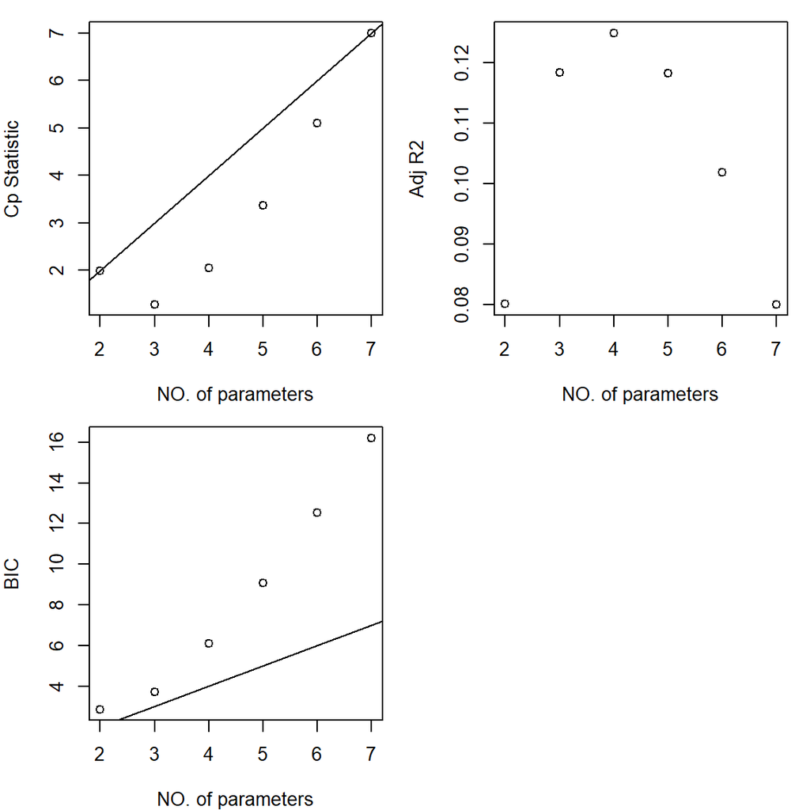

```r
par(mar=c(4,4,1,1))
par(mfrow=c(2,2))

plot(2:7, rs$cp, xlab="NO. of parameters", ylab="Cp Statistic")
abline(0,1)

plot(2:7, rs$adjr2, xlab="NO. of parameters", ylab="Adj R2")

plot(2:7, rs$bic, xlab="NO. of parameters", ylab="BIC")
abline(0,1)
```

Compare models with 2, 3, 4 predictors

```r
hate_crime_reg_df %>%
  nest(state:hate_crimes_per_100k_splc) %>%
  mutate(
    multi_fit_2 =
      map(.x = data, ~lm(hate_crimes_per_100k_splc ~ perc_population_with_high_school_degree + gini_index, data=.x)),
multi_fit_3 =
  map(.x = data, ~lm(hate_crimes_per_100k_splc ~ unemployment + perc_population_with_high_school_degree + gini_index, data=.x)),
multi_fit_4 =
  map(.x = data, ~lm(hate_crimes_per_100k_splc ~ unemployment + perc_population_with_high_school_degree + gini_index + urbanization, data=.x))
  ) %>%
  pivot_longer(
    multi_fit_2:multi_fit_4,
    names_to = "model",
    values_to = "results"
  ) %>%
  mutate(
    AIC = map(.x = results, ~AIC(.x)),
    BIC = map(.x = results, ~BIC(.x)),
    C_p = map(.x = results, ~ols_mallows_cp(.x, fit_all_no_citizen)),
    adj_r_sq = map(.x = results, ~summary(.x)$adj.r.squared)
  ) %>%
  unnest(AIC:adj_r_sq)
```

```
## # A tibble: 3 x 7
##   data              model       results   AIC   BIC   C_p adj_r_sq
##   <list>            <chr>       <list>  <dbl> <dbl> <dbl>    <dbl>
## 1 <tibble [44 x 8]> multi_fit_2 <lm>     78.1  85.2  1.29    0.118
## 2 <tibble [44 x 8]> multi_fit_3 <lm>     78.7  87.6  2.05    0.125
## 3 <tibble [44 x 8]> multi_fit_4 <lm>     79.9  90.6  3.38    0.118
```

(Note: BIC is more conservative than AIC by penalizing more on the number of parameters)

Note that the adjusted R2, BIC and Cp are calculated on the training data that have been used to fit the model. This means that, the model selection, using these metrics, is possibly subject to overfitting and may not perform as well when applied to new data.

A more rigorous approach is to select a models based on the prediction error computed on a new test data using k-fold cross-validation techniques.

## K-fold CV

```r
cv_df =
  hate_crime_reg_df %>%
  crossv_mc(1000) %>%
  mutate(
    train = map(train, as_tibble),
    test = map(test, as_tibble)
  ) %>%
  mutate(
    multi_fit_2 = map(.x = train, ~lm(hate_crimes_per_100k_splc ~ perc_population_with_high_school_degree + gini_index, data=.x)),
multi_fit_3 =
  map(.x = train, ~lm(hate_crimes_per_100k_splc ~ unemployment + perc_population_with_high_school_degree + gini_index, data=.x)),
multi_fit_4 =
  map(.x = train, ~lm(hate_crimes_per_100k_splc ~ unemployment + perc_population_with_high_school_degree + gini_index + urbanization, data=.x))
      ) %>%
  mutate(
    rmse_mod_2_preds = map2_dbl(multi_fit_2, test, ~rmse(model = .x, data = .y)),
    rmse_mode_3_preds = map2_dbl(multi_fit_3, test, ~rmse(model = .x, data = .y)),
    rmse_model_4_preds = map2_dbl(multi_fit_4, test, ~rmse(model = .x, data = .y)))
```

Make plots of RMSE vs model

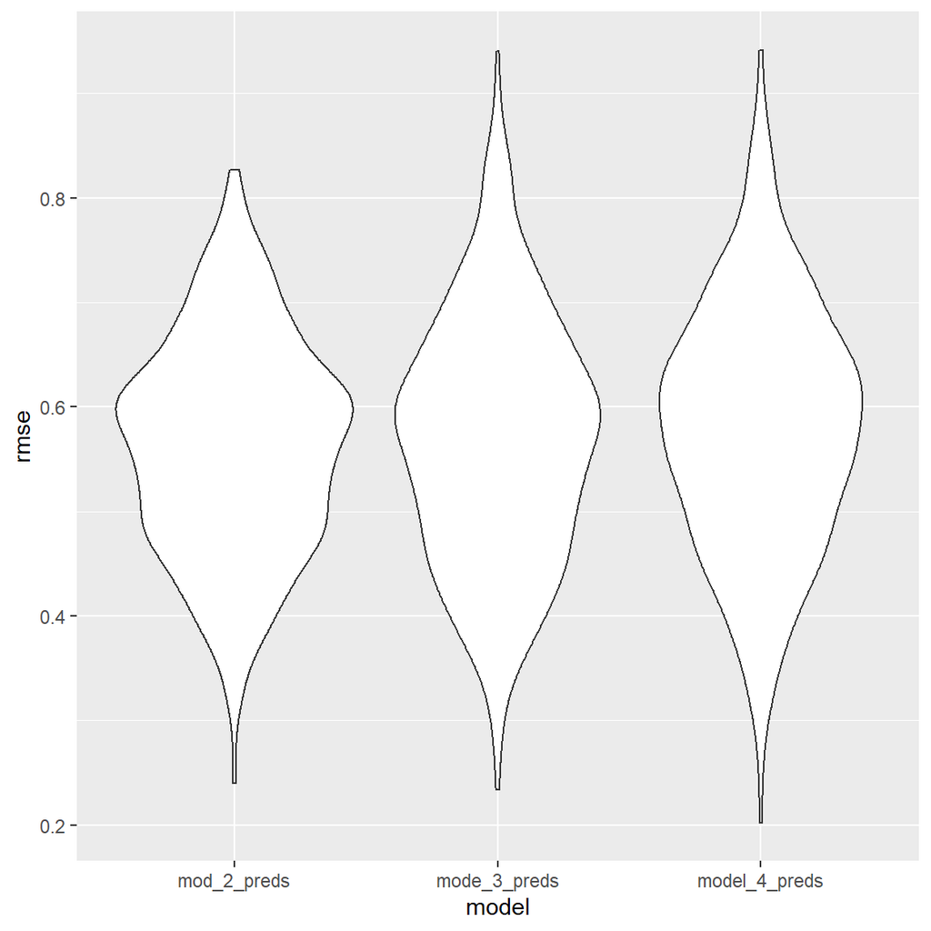

```r
cv_df %>%
   dplyr::select(starts_with("rmse")) %>%
  pivot_longer(
    everything(),
    names_to = "model",
    values_to = "rmse",
    names_prefix = "rmse_") %>%
  mutate(model = fct_inorder(model)) %>%
  ggplot(aes(x = model, y = rmse)) + geom_violin()
```

We decide to choose the model with two predictors: perc_population_with_high_school_degree and gini_index

```r
multi_fit_start = lm(hate_crimes_per_100k_splc ~ perc_population_with_high_school_degree + gini_index, data=hate_crime_reg_df)

broom::tidy(multi_fit_start) %>%
  knitr::kable(digits = 3)
```

| term | estimate | std.error | statistic | p.value |
| --- | --- | --- | --- | --- |
| (Intercept) | -14.611 | 5.359 | -2.726 | 0.009 |
| perc_population_with_high_school_degree | 9.509 | 3.419 | 2.781 | 0.008 |
| gini_index | 10.811 | 6.429 | 1.682 | 0.100 |

## Model Modification

### Interaction between Gini Index and Unemployment

Our previous selected model

```r
model_select = lm(hate_crimes_per_100k_splc ~ perc_population_with_high_school_degree + gini_index, data=hate_crime_reg_df)

summary(model_select)
```

```
##
## Call:
## lm(formula = hate_crimes_per_100k_splc ~ perc_population_with_high_school_degree +
##     gini_index, data = hate_crime_reg_df)
##
## Residuals:
##      Min       1Q   Median       3Q      Max
## -1.26341 -0.43818  0.03534  0.42669  1.10132
##
## Coefficients:
##                                         Estimate Std. Error t value Pr(>|t|)
## (Intercept)                              -14.611      5.359  -2.726  0.00938 **
## perc_population_with_high_school_degree    9.509      3.419   2.781  0.00814 **
## gini_index                                10.811      6.429   1.682  0.10025
## ---
## Signif. codes:  0 '***' 0.001 '**' 0.01 '*' 0.05 '.' 0.1 ' ' 1
##
## Residual standard error: 0.556 on 41 degrees of freedom
## Multiple R-squared:  0.1595, Adjusted R-squared:  0.1185
## F-statistic: 3.889 on 2 and 41 DF,  p-value: 0.02841
```

stratify by unemployment

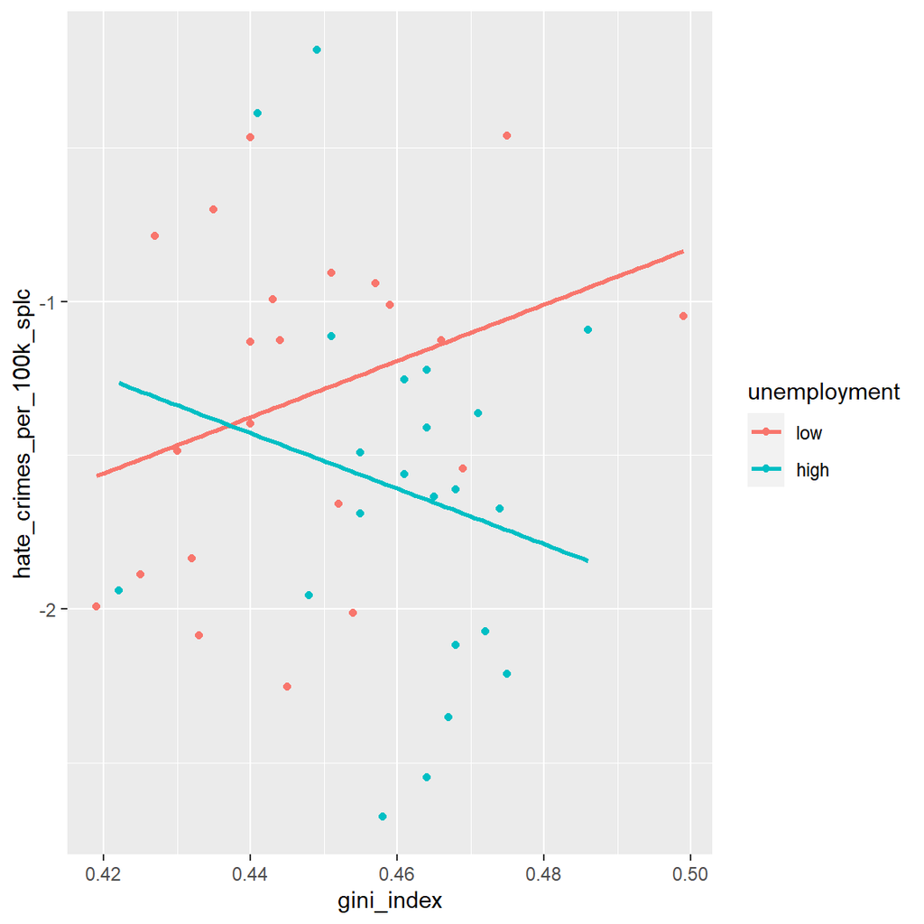

```r
hate_crime_reg_df %>%
  ggplot(aes(x = gini_index, y = hate_crimes_per_100k_splc, color = unemployment)) +
  geom_point() +
  geom_smooth(method = "lm", se = F)
```

The two line are not parallel

Add interaction between gini index and unemployment to the model

```r
multi_fit = lm(hate_crimes_per_100k_splc ~  perc_population_with_high_school_degree + gini_index*unemployment, data = hate_crime_reg_df)

summary(multi_fit)
```

```
##
## Call:
## lm(formula = hate_crimes_per_100k_splc ~ perc_population_with_high_school_degree +
##     gini_index * unemployment, data = hate_crime_reg_df)
##
## Residuals:
##      Min       1Q   Median       3Q      Max
## -1.12041 -0.38865  0.07787  0.32917  1.09638
##
## Coefficients:
##                                         Estimate Std. Error t value Pr(>|t|)
## (Intercept)                              -16.897      5.517  -3.063  0.00396 **
## perc_population_with_high_school_degree    8.427      3.474   2.426  0.02000 *
## gini_index                                18.247      7.338   2.487  0.01728 *
## unemploymenthigh                           8.235      4.933   1.669  0.10303
## gini_index:unemploymenthigh              -18.526     10.804  -1.715  0.09434 .
## ---
## Signif. codes:  0 '***' 0.001 '**' 0.01 '*' 0.05 '.' 0.1 ' ' 1
##
## Residual standard error: 0.541 on 39 degrees of freedom
## Multiple R-squared:  0.2431, Adjusted R-squared:  0.1654
## F-statistic: 3.131 on 4 and 39 DF,  p-value: 0.02515
```

```r
broom::tidy(multi_fit) %>%
  knitr::kable(digits = 3)
```

| term | estimate | std.error | statistic | p.value |
| --- | --- | --- | --- | --- |
| (Intercept) | -16.897 | 5.517 | -3.063 | 0.004 |
| perc_population_with_high_school_degree | 8.427 | 3.474 | 2.426 | 0.020 |
| gini_index | 18.247 | 7.338 | 2.487 | 0.017 |
| unemploymenthigh | 8.235 | 4.933 | 1.669 | 0.103 |
| gini_index:unemploymenthigh | -18.526 | 10.804 | -1.715 | 0.094 |

ANOVA

```r
anova(multi_fit)
```

```
## Analysis of Variance Table
##
## Response: hate_crimes_per_100k_splc
##                                         Df  Sum Sq Mean Sq F value  Pr(>F)
## perc_population_with_high_school_degree  1  1.5304 1.53038  5.2289 0.02773 *
## gini_index                               1  0.8742 0.87421  2.9869 0.09185 .
## unemployment                             1  0.4003 0.40030  1.3677 0.24930
## gini_index:unemployment                  1  0.8605 0.86053  2.9402 0.09434 .
## Residuals                               39 11.4144 0.29268
## ---
## Signif. codes:  0 '***' 0.001 '**' 0.01 '*' 0.05 '.' 0.1 ' ' 1
```

ANOVA Comparison

```r
anova(model_select,multi_fit)
```

```
## Analysis of Variance Table
##
## Model 1: hate_crimes_per_100k_splc ~ perc_population_with_high_school_degree +
##     gini_index
## Model 2: hate_crimes_per_100k_splc ~ perc_population_with_high_school_degree +
##     gini_index * unemployment
##   Res.Df    RSS Df Sum of Sq     F Pr(>F)
## 1     41 12.675
## 2     39 11.414  2    1.2608 2.154 0.1296
```

Stratified models

Low unemployment: A positive, statistically significant association b/w gini index and hate crime rate

```r
reg_low_unemp_df =
hate_crime_reg_df %>%
  filter(unemployment == "low")

multi_fit_low_unemp =
  lm(hate_crimes_per_100k_splc ~ perc_population_with_high_school_degree + gini_index, data = reg_low_unemp_df)

summary(multi_fit_low_unemp)
```

```
##
## Call:
## lm(formula = hate_crimes_per_100k_splc ~ perc_population_with_high_school_degree +
##     gini_index, data = reg_low_unemp_df)
##
## Residuals:
##      Min       1Q   Median       3Q      Max
## -1.04757 -0.38892  0.09688  0.34322  0.66520
##
## Coefficients:
##                                         Estimate Std. Error t value Pr(>|t|)
## (Intercept)                              -18.315      6.736  -2.719   0.0136 *
## perc_population_with_high_school_degree    9.466      4.580   2.067   0.0527 .
## gini_index                                19.370      7.480   2.590   0.0180 *
## ---
## Signif. codes:  0 '***' 0.001 '**' 0.01 '*' 0.05 '.' 0.1 ' ' 1
##
## Residual standard error: 0.4811 on 19 degrees of freedom
## Multiple R-squared:  0.2672, Adjusted R-squared:   0.19
## F-statistic: 3.463 on 2 and 19 DF,  p-value: 0.05219
```

High unemployment: A negative, but not statistically significant association b/w gini index and hate crime rate

```r
reg_high_unemp_df =
hate_crime_reg_df %>%
  filter(unemployment == "high")

multi_fit_high_unemp =
  lm(hate_crimes_per_100k_splc ~  perc_population_with_high_school_degree + gini_index, data = reg_high_unemp_df)

summary(multi_fit_high_unemp)
```

```
##
## Call:
## lm(formula = hate_crimes_per_100k_splc ~ perc_population_with_high_school_degree +
##     gini_index, data = reg_high_unemp_df)
##
## Residuals:
##     Min      1Q  Median      3Q     Max
## -1.0980 -0.3307  0.0493  0.2871  1.1200
##
## Coefficients:
##                                         Estimate Std. Error t value Pr(>|t|)
## (Intercept)                               -7.510      8.353  -0.899    0.380
## perc_population_with_high_school_degree    7.560      5.277   1.433    0.168
## gini_index                                -1.178     11.257  -0.105    0.918
##
## Residual standard error: 0.6067 on 19 degrees of freedom
## Multiple R-squared:  0.1321, Adjusted R-squared:  0.04075
## F-statistic: 1.446 on 2 and 19 DF,  p-value: 0.2603
```

### Interaction between gini index and urbanization

stratify by urbanization

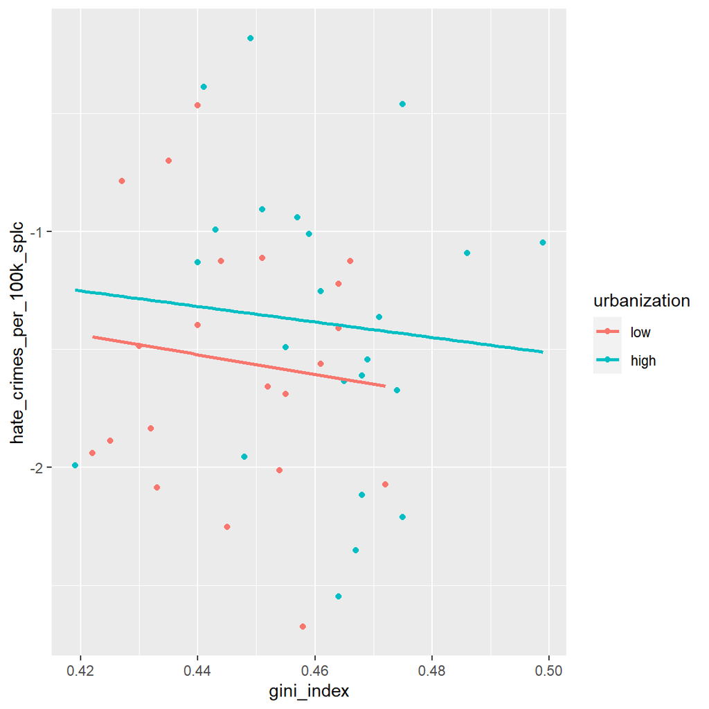

```r
hate_crime_reg_df %>%
  ggplot(aes(x = gini_index, y = hate_crimes_per_100k_splc, color = urbanization)) +
  geom_point() +
  geom_smooth(method = "lm", se = F)
```

The two line are parallel. There is no interaction between gini index and urbanization

## K-fold CV

```r
cv_df_2 =
  hate_crime_reg_df %>%
  crossv_mc(1000) %>%
  mutate(
    model_small = map(train, ~lm(hate_crimes_per_100k_splc ~  perc_population_with_high_school_degree + gini_index, data = .x)),
    model_large = map(train, ~lm(hate_crimes_per_100k_splc ~  perc_population_with_high_school_degree + gini_index*unemployment,data = .x))
  ) %>%

  mutate(
    rmse_model_small = map2_dbl(model_small, test, ~rmse(model = .x, data = .y)),
    rmse_model_large = map2_dbl(model_large, test, ~rmse(model = .x, data = .y))
  )
```

Make plots of RMSE vs model

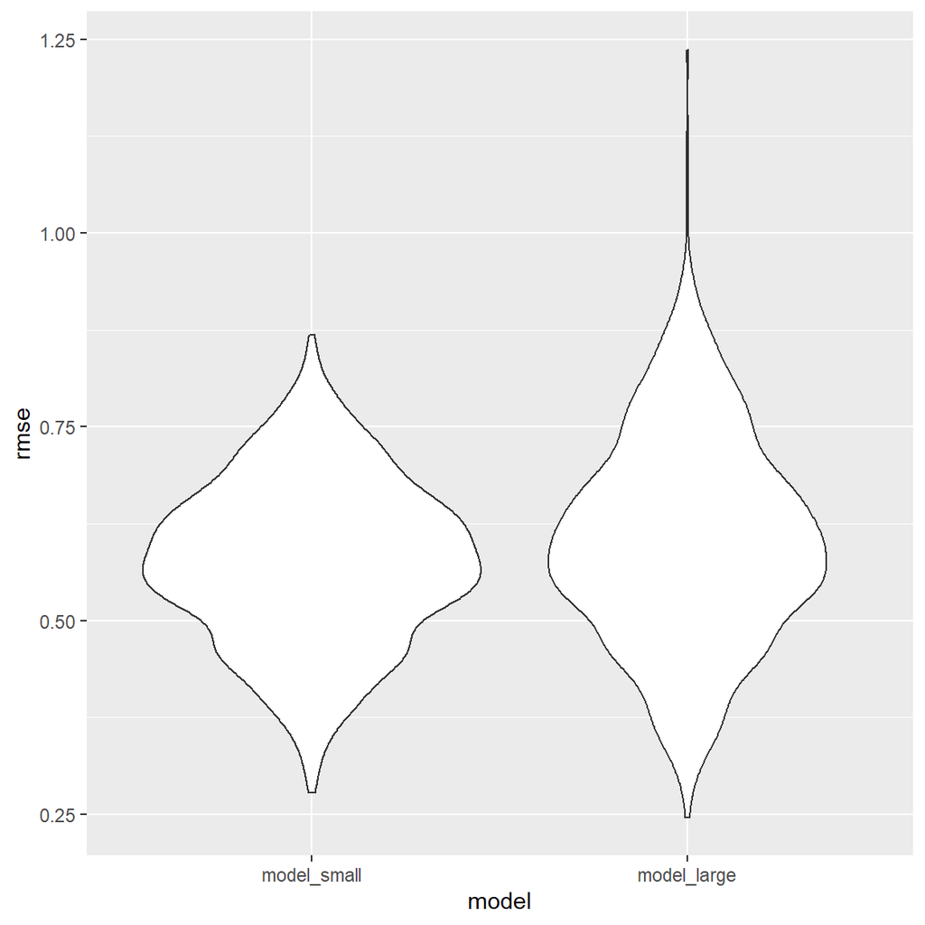

```r
cv_df_2 %>%
   dplyr::select(starts_with("rmse")) %>%
  pivot_longer(
    everything(),
    names_to = "model",
    values_to = "rmse",
    names_prefix = "rmse_") %>%
  mutate(model = fct_inorder(model)) %>%
  ggplot(aes(x = model, y = rmse)) + geom_violin()
```

## Model diagnostic

Check model assumption

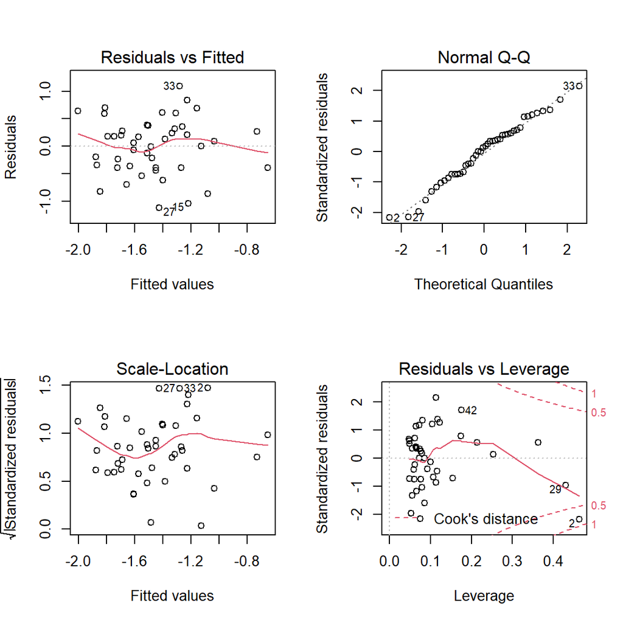

```r
par(mfrow=c(2,2))
plot(multi_fit)
```

indentify potential influential outlier observation 2

exclude observation2 to see its impact to the model

```r
hate_crime_reg_no2 =
  hate_crime_reg_df[-c(2),]

multi_fit_no2 = lm(hate_crimes_per_100k_splc ~  perc_population_with_high_school_degree + gini_index*unemployment, data = hate_crime_reg_no2)

summary(multi_fit_no2)
```

```
##
## Call:
## lm(formula = hate_crimes_per_100k_splc ~ perc_population_with_high_school_degree +
##     gini_index * unemployment, data = hate_crime_reg_no2)
##
## Residuals:
##      Min       1Q   Median       3Q      Max
## -1.17992 -0.38884  0.05736  0.37318  0.78865
##
## Coefficients:
##                                         Estimate Std. Error t value Pr(>|t|)
## (Intercept)                              -18.908      5.312  -3.559  0.00102 **
## perc_population_with_high_school_degree    9.900      3.361   2.945  0.00548 **
## gini_index                                19.839      7.003   2.833  0.00734 **
## unemploymenthigh                          15.921      5.763   2.762  0.00879 **
## gini_index:unemploymenthigh              -34.996     12.532  -2.793  0.00814 **
## ---
## Signif. codes:  0 '***' 0.001 '**' 0.01 '*' 0.05 '.' 0.1 ' ' 1
##
## Residual standard error: 0.5138 on 38 degrees of freedom
## Multiple R-squared:  0.3244, Adjusted R-squared:  0.2533
## F-statistic: 4.562 on 4 and 38 DF,  p-value: 0.00416
```

```r
broom::tidy(multi_fit_no2) %>%
  knitr::kable(digits = 3)
```

| term | estimate | std.error | statistic | p.value |
| --- | --- | --- | --- | --- |
| (Intercept) | -18.908 | 5.312 | -3.559 | 0.001 |
| perc_population_with_high_school_degree | 9.900 | 3.361 | 2.945 | 0.005 |
| gini_index | 19.839 | 7.003 | 2.833 | 0.007 |
| unemploymenthigh | 15.921 | 5.763 | 2.762 | 0.009 |
| gini_index:unemploymenthigh | -34.996 | 12.532 | -2.793 | 0.008 |

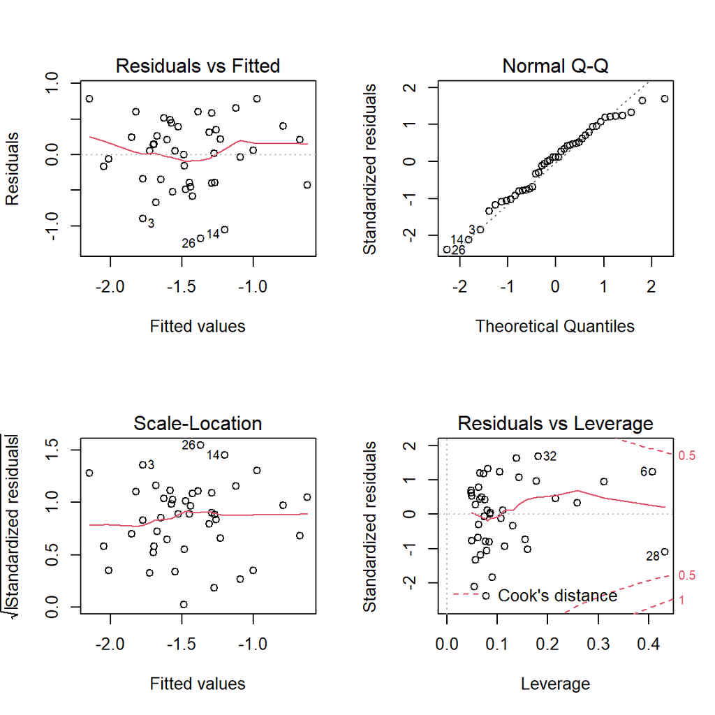

```r
par(mfrow=c(2,2))
plot(multi_fit_no2)
```

Second time cross validation

```r
cv_df_3 =
  hate_crime_reg_no2 %>%
  crossv_mc(1000) %>%
  mutate(
    model_small = map(train, ~lm(hate_crimes_per_100k_splc ~  perc_population_with_high_school_degree + gini_index, data = .x)),
    model_large = map(train, ~lm(hate_crimes_per_100k_splc ~  perc_population_with_high_school_degree + gini_index*unemployment,data = .x))
  ) %>%

  mutate(
    rmse_model_small = map2_dbl(model_small, test, ~rmse(model = .x, data = .y)),
    rmse_model_large = map2_dbl(model_large, test, ~rmse(model = .x, data = .y))
  )
```

Make plots of RMSE vs model

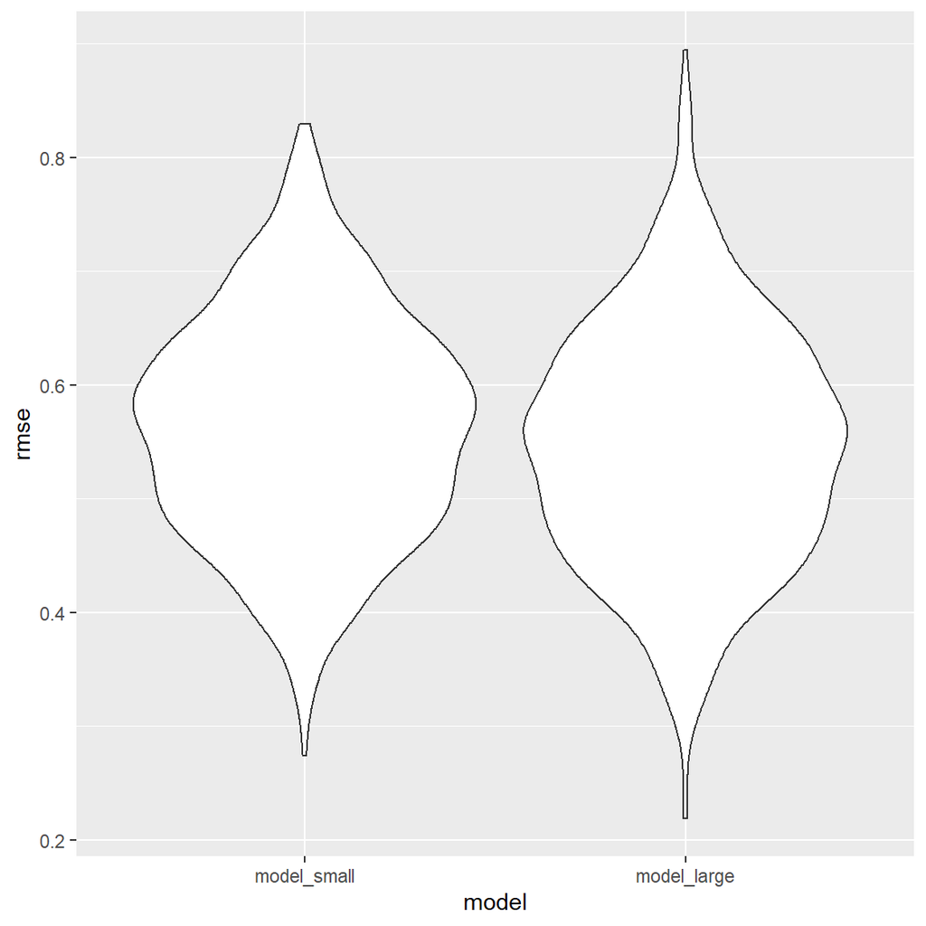

```r
cv_df_3 %>%
   dplyr::select(starts_with("rmse")) %>%
  pivot_longer(
    everything(),
    names_to = "model",
    values_to = "rmse",
    names_prefix = "rmse_") %>%
  mutate(model = fct_inorder(model)) %>%
  ggplot(aes(x = model, y = rmse)) + geom_violin()
```